# Group Data Analysis

Group hisa’R’üstü

> Editing Data

These data, in the 81 provinces of Turkey contains the information first-hand and second-hand home sales. These data, in the 81 provinces of Turkey contains the information first-hand and second-hand home sales. Migration movements in cities, economic movements throughout the country and some changes in cities (such as opening factories) are some of the factors that affect home sales data. Some packages need to be used to analyze the data. First of all, these packages were included and the data was taken from csv file. In order to observe the content of our group data, the head and the tale part were printed.

After the 92nd row, rows gives information about the numerical . Therefore, numerical data was separated from these information rows and put into another data set.

```r
datainfo = evds[c(92:1080),]
evds = evds[c(1:91),]
head(evds[,c(1:5)])
```

```
##     Tarih TP.AKONUTSAT3.TOPLAM TP.AKONUTSAT3.T1 TP.AKONUTSAT3.T2
## 1 2013-01            39,163.00           591.00              109
## 2 2013-02            39,521.00           691.00              197
## 3 2013-03            43,052.00           705.00              130
## 4 2013-04            41,233.00           746.00              115
## 5 2013-05            46,049.00           699.00              135
## 6 2013-06            43,345.00           777.00              145
##   TP.AKONUTSAT3.K3
## 1              175
## 2              163
## 3              203
## 4              184
## 5              251
## 6              202
```

```r
tail(evds[,c(1:5)])
```

```
##      Tarih TP.AKONUTSAT3.TOPLAM TP.AKONUTSAT3.T1 TP.AKONUTSAT3.T2
## 86 2020-02            37,303.00           872.00              134
## 87 2020-03            34,089.00           812.00              169
## 88 2020-04            14,848.00           445.00              146
## 89 2020-05            16,860.00           500.00              146
## 90 2020-06            58,632.00         1,556.00              376
## 91 2020-07            67,937.00         1,555.00              338
##    TP.AKONUTSAT3.K3
## 86              265
## 87              222
## 88              114
## 89              148
## 90              499
## 91              513
```

```r
for(i in c(1:165)){
  evds[,i] <- gsub(",","",evds[,i])
}

evds[, c(2:165)] <- sapply(evds[, c(2:165)], as.numeric)

names(evds)[1] = "Date"
```

In order to convert the Date column to a date format, it was necessary to add days to the Date. That’s why the day was added to the Date column.

```r
evds$Date = paste(evds$Date,"01",sep="-")

evds = evds %>%
  mutate(Date=as.Date(Date, format="%Y-%m-%d")) %>%
  mutate(Year=year(Date), Month=month(Date))

head(evds, 10)
```

```
##          Date TP.AKONUTSAT3.TOPLAM TP.AKONUTSAT3.T1 TP.AKONUTSAT3.T2
## 1  2013-01-01                39163              591              109
## 2  2013-02-01                39521              691              197
## 3  2013-03-01                43052              705              130
## 4  2013-04-01                41233              746              115
## 5  2013-05-01                46049              699              135
## 6  2013-06-01                43345              777              145
## 7  2013-07-01                49224              781              182
## 8  2013-08-01                38817              549              162
## 9  2013-09-01                46778              637              188
## 10 2013-10-01                35363              459              140
##    TP.AKONUTSAT3.K3 TP.AKONUTSAT3.T4 TP.AKONUTSAT3.T5 TP.AKONUTSAT3.T6
## 1               175               71              158              114
## 2               163              181              113              174
## 3               203               64              166              171
```

[output cut: 447 more lines]

In the data analysis process, a season column may be required to examine the relationship between sales data and seasons, so the season column was created.

```r
find_season <- function(mon){
  season = NULL

  if(between(mon, 3, 5)){
    season = "Spring"
  } else if(between(mon, 6, 8)){
    season = "Summer"
  } else if(between(mon, 9, 11)){
    season = "Fall"
  } else{
    season = "Winter"
  }

  return(season)
}

evds$Season = sapply(evds$Month, find_season)

head(evds, 10)
```

```
##          Date TP.AKONUTSAT3.TOPLAM TP.AKONUTSAT3.T1 TP.AKONUTSAT3.T2
## 1  2013-01-01                39163              591              109
## 2  2013-02-01                39521              691              197
## 3  2013-03-01                43052              705              130
## 4  2013-04-01                41233              746              115
## 5  2013-05-01                46049              699              135
## 6  2013-06-01                43345              777              145
## 7  2013-07-01                49224              781              182
## 8  2013-08-01                38817              549              162
## 9  2013-09-01                46778              637              188
## 10 2013-10-01                35363              459              140
##    TP.AKONUTSAT3.K3 TP.AKONUTSAT3.T4 TP.AKONUTSAT3.T5 TP.AKONUTSAT3.T6
## 1               175               71              158              114
## 2               163              181              113              174
## 3               203               64              166              171
```

[output cut: 447 more lines]

```r
head(names(evds),50)
```

```
##  [1] "Date"                 "TP.AKONUTSAT3.TOPLAM" "TP.AKONUTSAT3.T1"
##  [4] "TP.AKONUTSAT3.T2"     "TP.AKONUTSAT3.K3"     "TP.AKONUTSAT3.T4"
##  [7] "TP.AKONUTSAT3.T5"     "TP.AKONUTSAT3.T6"     "TP.AKONUTSAT3.T7"
## [10] "TP.AKONUTSAT3.T8"     "TP.AKONUTSAT3.T9"     "TP.AKONUTSAT3.T10"
## [13] "TP.AKONUTSAT3.T11"    "TP.AKONUTSAT3.T12"    "TP.AKONUTSAT3.T13"
## [16] "TP.AKONUTSAT3.T14"    "TP.AKONUTSAT3.T15"    "TP.AKONUTSAT3.T16"
## [19] "TP.AKONUTSAT3.T17"    "TP.AKONUTSAT3.T18"    "TP.AKONUTSAT3.T19"
## [22] "TP.AKONUTSAT3.T20"    "TP.AKONUTSAT3.T21"    "TP.AKONUTSAT3.T22"
## [25] "TP.AKONUTSAT3.T23"    "TP.AKONUTSAT3.T24"    "TP.AKONUTSAT3.T25"
## [28] "TP.AKONUTSAT3.T26"    "TP.AKONUTSAT3.T27"    "TP.AKONUTSAT3.T28"
## [31] "TP.AKONUTSAT3.T29"    "TP.AKONUTSAT3.T30"    "TP.AKONUTSAT3.T31"
## [34] "TP.AKONUTSAT3.T32"    "TP.AKONUTSAT3.T33"    "TP.AKONUTSAT3.T34"
## [37] "TP.AKONUTSAT3.T35"    "TP.AKONUTSAT3.T36"    "TP.AKONUTSAT3.T37"
## [40] "TP.AKONUTSAT3.T38"    "TP.AKONUTSAT3.T39"    "TP.AKONUTSAT3.T40"
## [43] "TP.AKONUTSAT3.T41"    "TP.AKONUTSAT3.T42"    "TP.AKONUTSAT3.T43"
## [46] "TP.AKONUTSAT3.T44"    "TP.AKONUTSAT3.T45"    "TP.AKONUTSAT3.T46"
## [49] "TP.AKONUTSAT3.T47"    "TP.AKONUTSAT3.T48"
```

As mentioned earlier, the data includes the sales numbers of second-hand and first-hand homes. Here it looked very complicated when naming data. To avoid this situation, the letter “F” was used for naming the first hand data and the letter “S” for the second hand.

```r
for(i in c(2:165)){
  name = names(evds)[i]
  splitted = unlist(strsplit(name, "\\."))
  if(splitted[2] == "AKONUTSAT3"){
    names(evds)[i] = paste("F",splitted[3],sep=".")
  } else if(splitted[2] == "AKONUTSAT4"){
    names(evds)[i] = paste("S",splitted[3],sep=".")
  }
}
names(evds)
```

```
##   [1] "Date"     "F.TOPLAM" "F.T1"     "F.T2"     "F.K3"     "F.T4"
##   [7] "F.T5"     "F.T6"     "F.T7"     "F.T8"     "F.T9"     "F.T10"
##  [13] "F.T11"    "F.T12"    "F.T13"    "F.T14"    "F.T15"    "F.T16"
##  [19] "F.T17"    "F.T18"    "F.T19"    "F.T20"    "F.T21"    "F.T22"
##  [25] "F.T23"    "F.T24"    "F.T25"    "F.T26"    "F.T27"    "F.T28"
##  [31] "F.T29"    "F.T30"    "F.T31"    "F.T32"    "F.T33"    "F.T34"
##  [37] "F.T35"    "F.T36"    "F.T37"    "F.T38"    "F.T39"    "F.T40"
##  [43] "F.T41"    "F.T42"    "F.T43"    "F.T44"    "F.T45"    "F.T46"
##  [49] "F.T47"    "F.T48"    "F.T49"    "F.T50"    "F.T51"    "F.T52"
##  [55] "F.T53"    "F.T54"    "F.T55"    "F.T56"    "F.T57"    "F.T58"
##  [61] "F.T59"    "F.T60"    "F.T61"    "F.T62"    "F.T63"    "F.T64"
##  [67] "F.T65"    "F.T66"    "F.T67"    "F.T68"    "F.T69"    "F.T70"
##  [73] "F.T71"    "F.T72"    "F.T73"    "F.T74"    "F.T75"    "F.T76"
##  [79] "F.T77"    "F.T78"    "F.T79"    "F.T80"    "F.T81"    "S.TOPLAM"
##  [85] "S.T1"     "S.T2"     "S.T3"     "S.K4"     "S.T5"     "S.T6"
##  [91] "S.T7"     "S.T8"     "S.T9"     "S.T10"    "S.T11"    "S.T12"
##  [97] "S.T13"    "S.T14"    "S.T15"    "S.T16"    "S.T17"    "S.T18"
## [103] "S.T19"    "S.T20"    "S.T21"    "S.T22"    "S.T23"    "S.T24"
## [109] "S.T25"    "S.T26"    "S.T27"    "S.T28"    "S.T29"    "S.T30"
## [115] "S.T31"    "S.T32"    "S.T33"    "S.T34"    "S.T35"    "S.T36"
## [121] "S.T37"    "S.T38"    "S.T39"    "S.T40"    "S.T41"    "S.T42"
## [127] "S.T43"    "S.T44"    "S.T45"    "S.T46"    "S.T47"    "S.T48"
## [133] "S.T49"    "S.T50"    "S.T51"    "S.T52"    "S.T53"    "S.T54"
## [139] "S.T55"    "S.T56"    "S.T57"    "S.T58"    "S.T59"    "S.T60"
## [145] "S.T61"    "S.T62"    "S.T63"    "S.T64"    "S.T65"    "S.T66"
## [151] "S.T67"    "S.T68"    "S.T69"    "S.T70"    "S.T71"    "S.T72"
## [157] "S.T73"    "S.T74"    "S.T75"    "S.T76"    "S.T77"    "S.T78"
## [163] "S.T79"    "S.T80"    "S.T81"    "Year"     "Month"    "Season"
```

When the data is checked carefully, there is some missing data. To guess what these missing data are: Total data was analyzed by collecting all data. As it is realized that it is equal, empty data (NA) are accepted as 0.

```r
evds[,c(2)] - rowSums(evds[,c(3:83)], na.rm = FALSE)
```

```
##  [1]  0  0 NA  0  0  0  0  0  0  0  0  0  0 NA  0  0  0  0  0  0  0  0  0  0  0
## [26]  0  0  0  0  0  0  0  0  0  0  0  0 NA  0  0 NA  0 NA  0  0  0  0  0  0  0
## [51]  0  0  0 NA  0  0  0  0  0  0  0  0  0  0  0  0  0  0  0  0  0  0  0  0 NA
## [76]  0  0  0  0  0  0  0  0  0  0  0  0  0  0  0  0
```

```r
evds[,c(2)] - rowSums(evds[,c(3:83)], na.rm = TRUE)
```

```
##  [1] 0 0 0 0 0 0 0 0 0 0 0 0 0 0 0 0 0 0 0 0 0 0 0 0 0 0 0 0 0 0 0 0 0 0 0 0 0 0
## [39] 0 0 0 0 0 0 0 0 0 0 0 0 0 0 0 0 0 0 0 0 0 0 0 0 0 0 0 0 0 0 0 0 0 0 0 0 0 0
## [77] 0 0 0 0 0 0 0 0 0 0 0 0 0 0 0
```

```r
evds[is.na(evds)] <- 0
```

> Analyzing the Data

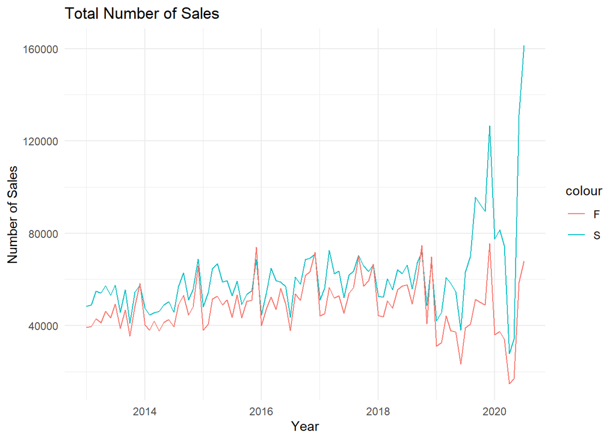

```r
ggplot(evds, aes(x=Date)) +
  geom_line(aes(y=S.TOPLAM, color="S")) +
  geom_line(aes(y=F.TOPLAM, color="F")) +
  theme_minimal() +
  ggtitle("Total Number of Sales") +
  labs(x = "Year", y = "Number of Sales")
```

Turkey the behavior of sales in general, the city has been interpreted by comparing the behavior of a relationship between them. As can be seen in the graph, the sales behavior of Adana is similar to the sales data across the country. We cannot generalize for every city, but we can say that the same criteria are effective across the country.

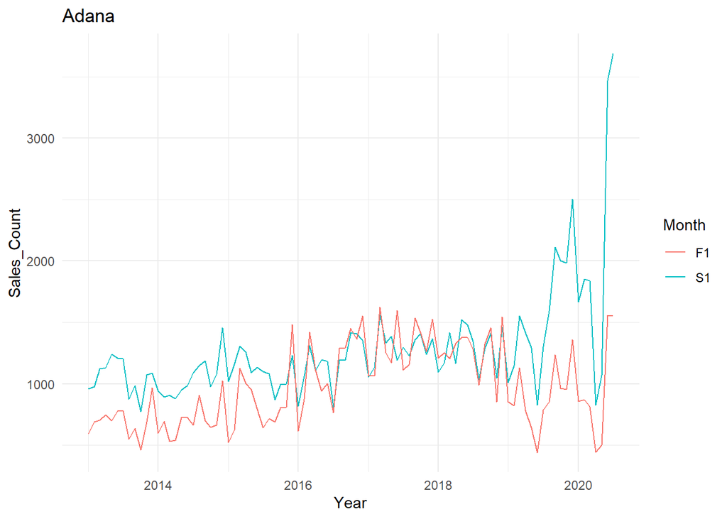

```r
ggplot(evds, aes(x=Date, color = Month)) +
  geom_line(aes(y=S.T1, color="S1")) +
  geom_line(aes(y=F.T1, color="F1")) +
  theme_minimal() +
  ggtitle("Adana") +
  labs(x = "Year", y = "Sales_Count")
```

The most advanced and largest city in Turkey: Ankara and Istanbul. Therefore, the sales data of these two cities were examined separately. When the data of the two cities are analyzed on the graph, the sales data of Istanbul is higher than Ankara. When the sum of the data of all cities is plotted, the total data of Ankara and Istanbul is very high compared to other cities.

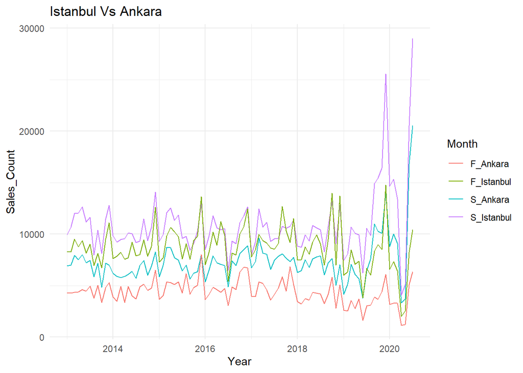

```r
ggplot(evds, aes(x=Date, color = Month)) +
  geom_line(aes(y=S.T7, color="S_Ankara")) +
  geom_line(aes(y=F.T7, color="F_Ankara")) +
  geom_line(aes(y=S.T40, color="S_Istanbul")) +
  geom_line(aes(y=F.T40, color="F_Istanbul")) +
  theme_minimal() +
  ggtitle("Istanbul Vs Ankara") +
  labs(x = "Year", y = "Sales_Count")
```

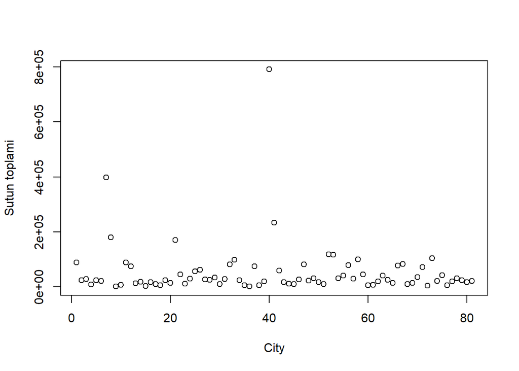

```r
plot(colSums(evds[,c(3:83)]),xlab = "City",ylab = "Sutun toplami")
```

By classifying the sales data of the cities according to the similarities of the movement, it is desired to analyze the sales behavior more logically. Therefore, all columns are scaled.

```r
evds.scaled=scale(evds[,c(2:165)])
head(evds.scaled)
```

```
##        F.TOPLAM       F.T1       F.T2       F.K3       F.T4       F.T5
## [1,] -0.7886184 -1.1683124 -1.3124424 -1.1610488 -0.3853212 -0.9924322
## [2,] -0.7575096 -0.8660452 -0.5425890 -1.2671552  2.2155321 -1.4295166
## [3,] -0.4506799 -0.8237278 -1.1287274 -0.9134672 -0.5508301 -0.9147284
## [4,] -0.6087437 -0.6997983 -1.2599524 -1.0814690 -1.2128654 -0.8758764
## [5,] -0.1902526 -0.8418638 -1.0849857 -0.4890417 -0.1961683 -0.2153934
## [6,] -0.4252193 -0.6060955 -0.9975024 -0.9223094 -0.6217624 -0.5941999
##            F.T6         F.T7       F.T8        F.T9       F.T10       F.T11
## [1,] -1.3156358 -0.086671233  0.2874488 -0.30705327 -0.90845467 -1.12704078
## [2,] -0.5758447 -0.074828767 -0.2124913 -0.52706782 -0.87679271 -1.17980921
## [3,] -0.6128343 -0.029150685  0.9532226 -0.19704600 -1.00344054  0.06904352
## [4,] -0.8347716 -0.003773973  0.4996185  0.02296855 -0.59183508 -0.62749969
## [5,] -0.1073104  0.197547945  1.3458585  0.57300492 -0.05358178 -0.70841128
## [6,] -0.0703208  0.074047945 -0.2441948  0.57300492  0.32636173 -1.07075446
##            F.T12      F.T13       F.T14      F.T15      F.T16     F.T17
```

[output cut: 181 more lines]

```r
fit <- kmeans(t(evds.scaled), 5)
mydata <- data.frame(t(evds.scaled), fit$cluster)

for(i in 1:5){
  print(row.names(mydata[(mydata$fit.cluster==i),]))
  print("")
}
```

```
##  [1] "F.T4"  "F.T7"  "F.T8"  "F.T9"  "F.T10" "F.T14" "F.T15" "F.T16" "F.T19"
## [10] "F.T23" "F.T24" "F.T26" "F.T28" "F.T30" "F.T32" "F.T36" "F.T40" "F.T43"
## [19] "F.T44" "F.T45" "F.T47" "F.T48" "F.T50" "F.T51" "F.T54" "F.T55" "F.T61"
## [28] "F.T64" "F.T66" "F.T68" "F.T72" "F.T75" "F.T76" "F.T78" "F.T80"
## [1] ""
##  [1] "S.TOPLAM" "S.T7"     "S.T8"     "S.T10"    "S.T21"    "S.T24"
##  [7] "S.T28"    "S.T29"    "S.T34"    "S.T40"    "S.T41"    "S.T47"
## [13] "S.T49"    "S.T52"    "S.T55"    "S.T58"    "S.T59"    "S.T61"
## [19] "S.T63"    "S.T65"    "S.T66"    "S.T73"    "S.T75"    "S.T79"
## [25] "S.T81"
## [1] ""
##  [1] "F.T60" "S.K4"  "S.T14" "S.T15" "S.T17" "S.T19" "S.T35" "S.T36" "S.T38"
## [10] "S.T45" "S.T51" "S.T57" "S.T60" "S.T68" "S.T72" "S.T78"
## [1] ""
##  [1] "S.T1"  "S.T2"  "S.T3"  "S.T5"  "S.T6"  "S.T11" "S.T12" "S.T13" "S.T16"
## [10] "S.T18" "S.T20" "S.T22" "S.T23" "S.T25" "S.T26" "S.T27" "S.T30" "S.T31"
## [19] "S.T32" "S.T33" "S.T37" "S.T39" "S.T42" "S.T43" "S.T44" "S.T46" "S.T48"
## [28] "S.T50" "S.T53" "S.T54" "S.T56" "S.T62" "S.T64" "S.T67" "S.T69" "S.T70"
## [37] "S.T71" "S.T74" "S.T77" "S.T80"
## [1] ""
##  [1] "F.TOPLAM" "F.T1"     "F.T2"     "F.K3"     "F.T5"     "F.T6"
##  [7] "F.T11"    "F.T12"    "F.T13"    "F.T17"    "F.T18"    "F.T20"
## [13] "F.T21"    "F.T22"    "F.T25"    "F.T27"    "F.T29"    "F.T31"
## [19] "F.T33"    "F.T34"    "F.T35"    "F.T37"    "F.T38"    "F.T39"
## [25] "F.T41"    "F.T42"    "F.T46"    "F.T49"    "F.T52"    "F.T53"
## [31] "F.T56"    "F.T57"    "F.T58"    "F.T59"    "F.T62"    "F.T63"
## [37] "F.T65"    "F.T67"    "F.T69"    "F.T70"    "F.T71"    "F.T73"
## [43] "F.T74"    "F.T77"    "F.T79"    "F.T81"    "S.T9"     "S.T76"
## [1] ""
```

First hand only city columns are scaled so that they are grouped by movement similarities.

```r
evdsF.scaled=scale(evds[,c(3:83)])
head(evdsF.scaled)
```

```
##            F.T1       F.T2       F.K3       F.T4       F.T5       F.T6
## [1,] -1.1683124 -1.3124424 -1.1610488 -0.3853212 -0.9924322 -1.3156358
## [2,] -0.8660452 -0.5425890 -1.2671552  2.2155321 -1.4295166 -0.5758447
## [3,] -0.8237278 -1.1287274 -0.9134672 -0.5508301 -0.9147284 -0.6128343
## [4,] -0.6997983 -1.2599524 -1.0814690 -1.2128654 -0.8758764 -0.8347716
## [5,] -0.8418638 -1.0849857 -0.4890417 -0.1961683 -0.2153934 -0.1073104
## [6,] -0.6060955 -0.9975024 -0.9223094 -0.6217624 -0.5941999 -0.0703208
##              F.T7       F.T8        F.T9       F.T10       F.T11       F.T12
## [1,] -0.086671233  0.2874488 -0.30705327 -0.90845467 -1.12704078 -0.94440806
## [2,] -0.074828767 -0.2124913 -0.52706782 -0.87679271 -1.17980921 -0.66312912
## [3,] -0.029150685  0.9532226 -0.19704600 -1.00344054  0.06904352 -0.36101470
## [4,] -0.003773973  0.4996185  0.02296855 -0.59183508 -0.62749969  0.13903674
## [5,]  0.197547945  1.3458585  0.57300492 -0.05358178 -0.70841128  0.19633430
## [6,]  0.074047945 -0.2441948  0.57300492  0.32636173 -1.07075446 -0.08494464
##           F.T13       F.T14      F.T15      F.T16     F.T17       F.T18
```

[output cut: 83 more lines]

```r
fit <- kmeans(t(evdsF.scaled), 15)
mydata <- data.frame(t(evdsF.scaled), fit$cluster)

for(i in 1:15){
  print(row.names(mydata[(mydata$fit.cluster==i),]))
  print("")
}
```

```
## [1] "F.T4"  "F.T14" "F.T26" "F.T45"
## [1] ""
## [1] "F.T78"
## [1] ""
## [1] "F.T36"
## [1] ""
## [1] "F.T9"  "F.T76"
## [1] ""
## [1] "F.T72"
## [1] ""
## [1] "F.T12" "F.T21" "F.T40" "F.T41" "F.T52" "F.T61" "F.T73"
## [1] ""
##  [1] "F.T1"  "F.T11" "F.T13" "F.T20" "F.T27" "F.T37" "F.T39" "F.T49" "F.T56"
## [10] "F.T77" "F.T79"
## [1] ""
```

[output cut: 17 more lines]

Only Second hand city columns are scaled so that they are grouped according to their motion similarity.

```r
evdsS.scaled=scale(evds[,c(85:165)])
head(evdsS.scaled)
```

```
##             S.T1       S.T2       S.T3       S.K4       S.T5       S.T6
## [1,] -0.70828036 -0.8174587 -0.6671844 -1.1369829 -0.4972146 -0.7748885
## [2,] -0.66675667 -0.0280719 -0.3183013 -1.5882176 -0.6873261 -0.9893062
## [3,] -0.34986533 -0.5104749 -0.1803707 -1.2431558 -0.9534822 -0.5747652
## [4,] -0.33238167 -0.6639668 -0.8781371  1.3580791 -0.8267412 -0.5175872
## [5,] -0.08542497 -0.3898742 -0.6834116 -0.3937729 -0.6112815 -0.4747036
## [6,] -0.15535961 -0.2802371 -1.0566354 -0.6857483 -0.6746520 -0.6319433
##             S.T7       S.T8       S.T9      S.T10      S.T11      S.T12
## [1,] -0.19411523 -0.5463673 -1.0664499 -0.8151579 -0.9883840 -1.3011934
## [2,] -0.17170438 -0.5726770 -1.0664499 -0.3132677 -1.0437480 -1.2424121
## [3,]  0.24031036 -0.1098648 -0.5265504 -0.4471051 -0.6008366 -0.9002210
## [4,]  0.05412797 -0.4028596 -0.3915755 -0.7482392 -0.7647990 -0.7952545
## [5,]  0.27435761 -0.1409582 -0.7965001 -1.0493733 -0.5028850 -0.6734932
## [6,] -0.07042461 -0.6145334 -0.5265504 -0.5809425 -0.9117263 -0.7196785
##           S.T13      S.T14      S.T15      S.T16      S.T17      S.T18
```

[output cut: 83 more lines]

```r
fit <- kmeans(t(evdsS.scaled), 5)
mydata <- data.frame(t(evdsS.scaled), fit$cluster)

for(i in 1:5){
  print(row.names(mydata[(mydata$fit.cluster==i),]))
  print("")
}
```

```
##  [1] "S.T7"  "S.T8"  "S.T10" "S.T21" "S.T24" "S.T28" "S.T34" "S.T40" "S.T41"
## [10] "S.T49" "S.T52" "S.T58" "S.T59" "S.T63" "S.T65" "S.T66" "S.T73" "S.T81"
## [1] ""
##  [1] "S.T1"  "S.T2"  "S.T3"  "S.T5"  "S.T6"  "S.T11" "S.T12" "S.T13" "S.T16"
## [10] "S.T18" "S.T20" "S.T22" "S.T23" "S.T25" "S.T26" "S.T27" "S.T30" "S.T31"
## [19] "S.T32" "S.T33" "S.T37" "S.T39" "S.T42" "S.T43" "S.T44" "S.T46" "S.T48"
## [28] "S.T53" "S.T54" "S.T56" "S.T62" "S.T64" "S.T67" "S.T70" "S.T71" "S.T74"
## [37] "S.T77"
## [1] ""
## [1] "S.T29" "S.T47" "S.T50" "S.T55" "S.T61" "S.T69" "S.T75" "S.T79" "S.T80"
## [1] ""
##  [1] "S.K4"  "S.T14" "S.T15" "S.T17" "S.T19" "S.T36" "S.T38" "S.T45" "S.T51"
## [10] "S.T57" "S.T60" "S.T68" "S.T72" "S.T78"
## [1] ""
## [1] "S.T9"  "S.T35" "S.T76"
## [1] ""
```

First hand only city columns used, not scaled so often grouped by size of numbers

```r
evdsF=evds[,c(3:83)]
head(evdsF)
```

```
##   F.T1 F.T2 F.K3 F.T4 F.T5 F.T6 F.T7 F.T8 F.T9 F.T10 F.T11 F.T12 F.T13 F.T14
## 1  591  109  175   71  158  114 4278 2101    5    49   651   639    62   111
## 2  691  197  163  181  113  174 4292 1896    3    50   636   693    59   132
## 3  705  130  203   64  166  171 4346 2374    6    46   991   751    74    94
## 4  746  115  184   36  170  153 4376 2188    8    59   793   847    74   159
## 5  699  135  251   79  238  212 4614 2535   13    76   770   858    82   192
## 6  777  145  202   61  199  215 4468 1883   13    88   667   804    64   169
##   F.T15 F.T16 F.T17 F.T18 F.T19 F.T20 F.T21 F.T22 F.T23 F.T24 F.T25 F.T26 F.T27
## 1     5   149     5    44   169    48  1568   354    55   319   438   555   130
## 2    13   123    11    52   198    62  1547   368    27   238   437   574   120
## 3     7   197     6    59   223    85  1631   417    56   281   444   711   113
## 4     5   135     6    36   220    77  1637   416    55   307   383   654   123
## 5     9   251     5    74   284    82  1680   518    62   291   571   774   145
## 6    22   168     9    44   272    97  1574   343    88   326   422   703   164
##   F.T28 F.T29 F.T30 F.T31 F.T32 F.T33 F.T34 F.T35 F.T36 F.T37 F.T38 F.T39 F.T40
```

[output cut: 34 more lines]

```r
fit <- kmeans(t(evdsF), 5)
mydata <- data.frame(t(evdsF), fit$cluster)

for(i in 1:5){
  print(row.names(mydata[(mydata$fit.cluster==i),]))
  print("")
}
```

```
##  [1] "F.T4"  "F.T6"  "F.T9"  "F.T10" "F.T13" "F.T14" "F.T15" "F.T16" "F.T17"
## [10] "F.T18" "F.T19" "F.T20" "F.T23" "F.T30" "F.T35" "F.T36" "F.T38" "F.T39"
## [19] "F.T43" "F.T44" "F.T45" "F.T48" "F.T50" "F.T51" "F.T60" "F.T61" "F.T62"
## [28] "F.T65" "F.T68" "F.T69" "F.T72" "F.T74" "F.T76" "F.T77" "F.T80" "F.T81"
## [1] ""
##  [1] "F.T1"  "F.T8"  "F.T11" "F.T12" "F.T21" "F.T32" "F.T33" "F.T37" "F.T47"
## [10] "F.T52" "F.T53" "F.T56" "F.T58" "F.T66" "F.T67" "F.T71" "F.T73"
## [1] ""
## [1] "F.T40"
## [1] ""
##  [1] "F.T2"  "F.K3"  "F.T5"  "F.T22" "F.T24" "F.T25" "F.T26" "F.T27" "F.T28"
## [10] "F.T29" "F.T31" "F.T34" "F.T42" "F.T46" "F.T49" "F.T54" "F.T55" "F.T57"
## [19] "F.T59" "F.T63" "F.T64" "F.T70" "F.T75" "F.T78" "F.T79"
## [1] ""
## [1] "F.T7"  "F.T41"
## [1] ""
```

evds2 contains what percentage of the values make up the total, maybe abnormal changes may be caught / a result may be reached:

```r
evds2 = evds
evds2[,c(2:83)] = evds2[,c(2:83)]*100/evds2[,2]
evds2[,c(84:165)] = evds2[,c(84:165)]*100/evds2[,84]
```

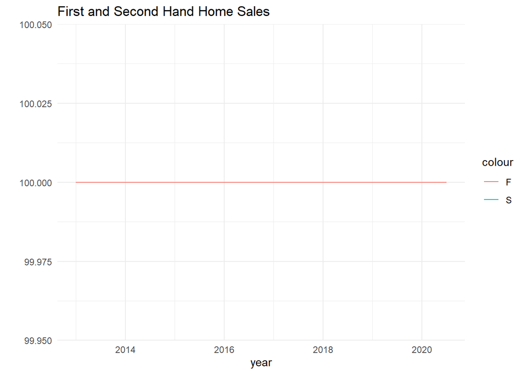

```r
ggplot(evds2, aes(x=Date)) +
  geom_line(aes(y=S.TOPLAM, color="S")) +
  geom_line(aes(y=F.TOPLAM, color="F")) +
  theme_minimal() +
  ggtitle("First and Second Hand Home Sales") +
  labs(x = "year", y = "")
```

```r
ege_bolge <- evds[,c(1,10,14,43,13,61,166,167,168)]
head(ege_bolge)
```

```
##         Date F.T8 F.T12 F.T41 F.T11 F.T59 Year Month Season
## 1 2013-01-01 2101   639  2189   651   389 2013     1 Winter
## 2 2013-02-01 1896   693  2225   636   420 2013     2 Winter
## 3 2013-03-01 2374   751  2461   991   478 2013     3 Spring
## 4 2013-04-01 2188   847  2331   793   443 2013     4 Spring
## 5 2013-05-01 2535   858  2514   770   451 2013     5 Spring
## 6 2013-06-01 1883   804  2599   667   483 2013     6 Summer
```

[figure not shown]

```r
ege_bolge %>%  group_by(Month,Season) %>% summarise(Sum = sum(F.T12)) %>%
  ggplot(data = ., aes(x = Month, y = Sum, fill = Season)) +
  geom_bar(stat="identity", position = position_dodge(), colour = "blue") +
  theme_minimal() +
  theme(legend.position="top")+
  labs(title = "Antalya")+
  geom_text(aes(label=Sum), vjust=1.6, color="black",
      position = position_dodge(0.9), size=3.5)
```

[figure not shown]

```r
ggplot(ege_bolge, aes(x=Month, y = ege_bolge[,c(2:2)], group = Year, colour = Season)) +
  geom_line() +
  theme_minimal() +
  theme(legend.position="top")+
  labs(title = "Balikesir")
```

[figure not shown]

```r
ggplot(evds, aes(x=Date, color = Month)) +
  geom_line(aes(y=S.T7, color="S_Ankara")) +
  geom_line(aes(y=F.T7, color="F_Ankara")) +
  geom_line(aes(y=S.T41, color="S_Istanbul")) +
  geom_line(aes(y=F.T41, color="F_Istanbul")) +
  theme_minimal() +
  ggtitle("Comparison") +
  labs(x = "Year", y = "Sales Count")
```

Total sales dats by years and seasons by selected cities in the aegean region with bar chart

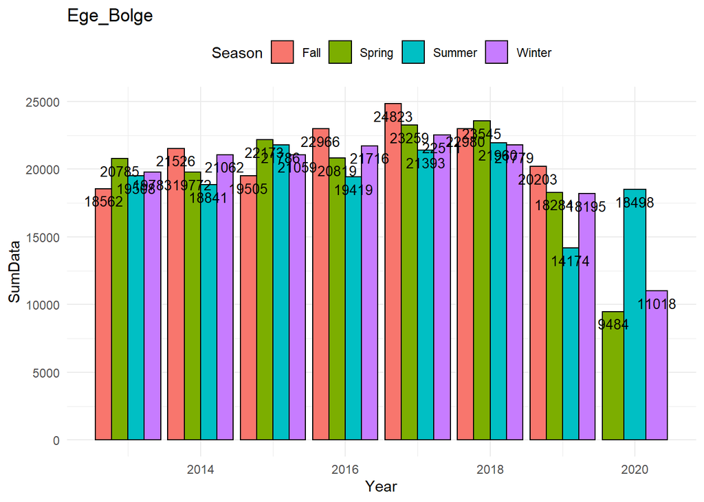

```r
#
ege_bolge %>% group_by(Year,Season) %>% summarise(SumData=sum(F.T8, F.T12, F.T41, F.T11, F.T59)) %>%
    ggplot(data = ., aes(x = Year, y = SumData, fill = Season)) +
      geom_bar(stat="identity", position = position_dodge(), colour = "black") +
      theme_minimal() +
      theme(legend.position="top")+
      labs(title = "Ege_Bolge")+
      geom_text(aes(label=SumData), vjust=1.6, color="black",
        position = position_dodge(0.9), size=3.5)
```